# Week 6 Performance Evaluation

February 21, 2020

## Overview of Topics

- Why we need an unbiased estimate of *TRUE* model performance
- Methods to evaluate model performance
- Metrics for classification model performance
- Additional metrics for regression models
- R/Python demo of model performance evaluation

## Overfitting

- Training accuracy vs.testing accuracy

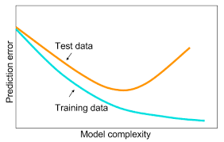

- Why neither training accuracy nor test accuracy is not good enough?

## Model Evaluation Methods (1)

- Unbiase methods
  - Hold-out method: createDataPartition()
  - Cross-validation method: createFolds()
  - Leave one out (Jackknife method)
  - Bootstrapping: createResample()
  - All of the above methods are also implemented in *caret* function trainControl() with method as “LGOCV” (Leave-Group-Out CV), “cv”, “repatedcv”, “LOOCV”, or “boot”/“boot632” respectively or in *sklearn* cross_validation module
- factors of comparison between different methods
  - Speed
  - Variability/reliability

## Model Evaluation Methods (2)

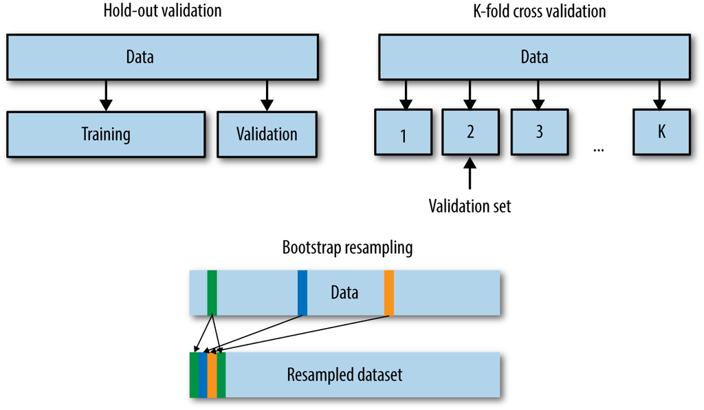

## Model Evaluation vs. Model Tuning

- Purpose of model performance evaluation
  - Get unbiased estimate of *TRUE* performance when the model is applied towards *unseen* data
  - Provide feedback for model hyperparameter tuning
- Model evaluation is not part of model hyperparameter tuning
  - if you get a better performance through one evaluation method, it doesn’t mean the model is better
  - don’t merely change evaluation method parameters in order to get a better model (same underlying models)

## Confusion Matrix

| Table | Predicted Positive | Predicted Negative |
| --- | --- | --- |
| Actual Positive | True Positive (TP) | False Negative (FN) |
| Actual Negative | False Positive (FP) | True Negative (TN) |

- Accuracy: percent of the predictions that are correct  
  \[ Accuracy = \frac{TP + TN}{TP + FP + FN + TN} \]

## Model Performance Metrics

- Accuracy
- Special challenges: imbalanced data
- Confusion matrix derived metrics
  - TP, FP, FN, TN,
    - FP (Type I error) vs. FN (Type II error)
    - Which type of error is worse: medical diagnostic, SPAM detection, criminal justice system, fraudence detection, etc.
  - Kappa Statistics
  - Precision vs. recall
  - F measure
  - Sensitivity vs. specificity

## Kappa Statistics

- Kappa (**\(\kappa\)**): measures inter-rater aggreement (or reliability) for qualitative (categorical) items.
  - \(\kappa = \frac{p_o-p_e}{1-p_e}\)
    - \(p_o\): observed agreement among raters
    - \(p_e\): hypothetical probability of chance agreement
- It is more robust by considering the possibility of the agreement occurring by chance.
  - Range: [0, 1]
  - 0 = agreement equivalent to chance; 1 = perfect agreement

## Precision, Recall and F-measure (1)

- Originates from information retrieval. Derived for each of possible class labels. such as Precision(Class = “Churn”), or Recall(Class = “Not Churn”) or F(Class = “Churn”)
- Precision (positive predictive value): percent of predicted positive that are correct (in IR context, fraction of relevant instances among the retrieved instances) \[ Precision = \frac{TP}{TP + FP} \]
- Recall (sensitivity): percent of positive cases that are correctly predicted (in IR context, fraction of the relevant documents that are successfully retrieved) \[ Recall = \frac{TP}{TP + FN} \]

## Precision, Recall and F-measure (2)

- F-measure (F1 or F score):
  - Balance between precision and recall (Harmonic Mean)
    - Harmonic mean is closer to the smaller value when precision and recall are different
    - Why? Example: naive classifier for a perfectly balanced dataset predicts all data points in one class, precision/recall/arithmetic mean/harmonic mean?
  - Range between 0 and 1 (perfect precision and recall) \[ F measure = \frac{2 * Precision * Recall}{Precision + Recall} \]

## Sensitivity vs. Specificity

- Often used in medical dignostic testings or screening study which have positive vs. negative testing results
- Sensitivity (True Positive Rate or TPR, or recall): Percent of positive cases correctly predicted, or coverage of actual positive cases
- Specificity (True Negative Rate or TNR): Percent of negative cases correctly predicted, or coverage of actual negative cases
- How does the pair of sensitivity and specificity cope with imbalanced data?

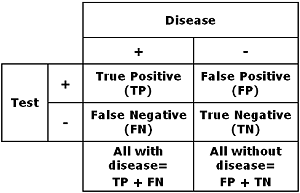

## Receiver Characteristic Curve (ROC)

- ROC plots Sensitivity vs. (1 - Specificity) or TPR vs. FPR
- Area Under Curve (AUC)
- ROC/AUC measure the model’s ability to distingush between the classes
  - based on the model’s predicted probability for target positive class label
  - inputs to ROC function: (Predicted Probability for Target Label, Target Label)

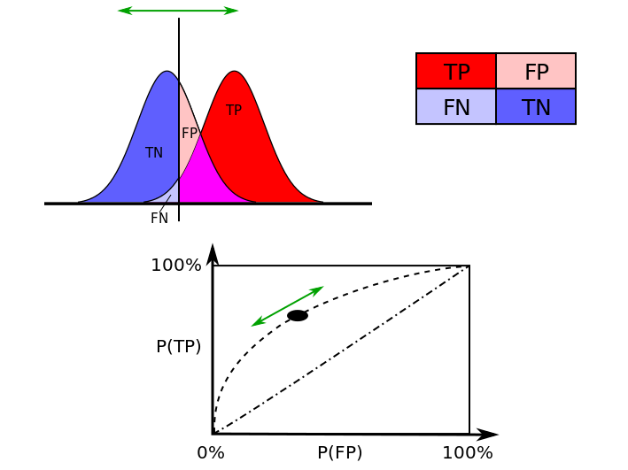

## Additional Model Performance Metrics

- Loss functions
- Classification
  - Log Loss or Cross Entropy
  - Hinge loss
- Regression
  - \(R^2\)
  - Sum of Squared Error (SSE) and its variants (MSE, RMSE, etc.)
  - Mean Absolute Error (MAE)

## Demo Dataset: Churn

```r
library(C50)
data(churn)
names(churnTrain)
```

```
##  [1] "state"                         "account_length"
##  [3] "area_code"                     "international_plan"
##  [5] "voice_mail_plan"               "number_vmail_messages"
##  [7] "total_day_minutes"             "total_day_calls"
##  [9] "total_day_charge"              "total_eve_minutes"
## [11] "total_eve_calls"               "total_eve_charge"
## [13] "total_night_minutes"           "total_night_calls"
## [15] "total_night_charge"            "total_intl_minutes"
## [17] "total_intl_calls"              "total_intl_charge"
## [19] "number_customer_service_calls" "churn"
```

```r
summary(churnTrain)
```

```
##      state      account_length          area_code    international_plan
##  WV     : 106   Min.   :  1.0   area_code_408: 838   no :3010
##  MN     :  84   1st Qu.: 74.0   area_code_415:1655   yes: 323
##  NY     :  83   Median :101.0   area_code_510: 840
##  AL     :  80   Mean   :101.1
##  OH     :  78   3rd Qu.:127.0
##  OR     :  78   Max.   :243.0
##  (Other):2824
##  voice_mail_plan number_vmail_messages total_day_minutes total_day_calls
##  no :2411        Min.   : 0.000        Min.   :  0.0     Min.   :  0.0
##  yes: 922        1st Qu.: 0.000        1st Qu.:143.7     1st Qu.: 87.0
##                  Median : 0.000        Median :179.4     Median :101.0
##                  Mean   : 8.099        Mean   :179.8     Mean   :100.4
##                  3rd Qu.:20.000        3rd Qu.:216.4     3rd Qu.:114.0
##                  Max.   :51.000        Max.   :350.8     Max.   :165.0
##
##  total_day_charge total_eve_minutes total_eve_calls total_eve_charge
##  Min.   : 0.00    Min.   :  0.0     Min.   :  0.0   Min.   : 0.00
##  1st Qu.:24.43    1st Qu.:166.6     1st Qu.: 87.0   1st Qu.:14.16
##  Median :30.50    Median :201.4     Median :100.0   Median :17.12
##  Mean   :30.56    Mean   :201.0     Mean   :100.1   Mean   :17.08
##  3rd Qu.:36.79    3rd Qu.:235.3     3rd Qu.:114.0   3rd Qu.:20.00
##  Max.   :59.64    Max.   :363.7     Max.   :170.0   Max.   :30.91
##
##  total_night_minutes total_night_calls total_night_charge
##  Min.   : 23.2       Min.   : 33.0     Min.   : 1.040
##  1st Qu.:167.0       1st Qu.: 87.0     1st Qu.: 7.520
##  Median :201.2       Median :100.0     Median : 9.050
##  Mean   :200.9       Mean   :100.1     Mean   : 9.039
##  3rd Qu.:235.3       3rd Qu.:113.0     3rd Qu.:10.590
##  Max.   :395.0       Max.   :175.0     Max.   :17.770
##
##  total_intl_minutes total_intl_calls total_intl_charge
##  Min.   : 0.00      Min.   : 0.000   Min.   :0.000
##  1st Qu.: 8.50      1st Qu.: 3.000   1st Qu.:2.300
##  Median :10.30      Median : 4.000   Median :2.780
##  Mean   :10.24      Mean   : 4.479   Mean   :2.765
##  3rd Qu.:12.10      3rd Qu.: 6.000   3rd Qu.:3.270
##  Max.   :20.00      Max.   :20.000   Max.   :5.400
##
##  number_customer_service_calls churn
##  Min.   :0.000                 yes: 483
##  1st Qu.:1.000                 no :2850
##  Median :1.000
##  Mean   :1.563
##  3rd Qu.:2.000
##  Max.   :9.000
##
```

## Model Training and Testing

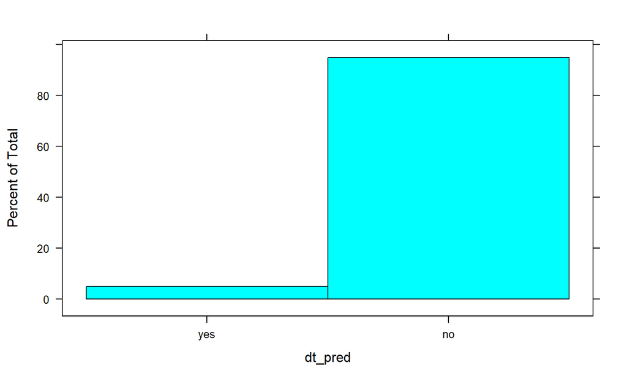

```r
library(caret)
library(rpart)
dt_model <- train(churn ~ ., data = churnTrain, method = "rpart")
dt_pred <- predict(dt_model, newdata = churnTest)
histogram(dt_pred)
```

## Check the Prediction Performance

```r
table(dt_pred, churnTest$churn)
```

```
##
## dt_pred  yes   no
##     yes   60   24
##     no   164 1419
```

```r
prop.table(table(dt_pred, churnTest$churn), margin = NULL)
```

```
##
## dt_pred        yes         no
##     yes 0.03599280 0.01439712
##     no  0.09838032 0.85122975
```

```r
confusionMatrix(dt_pred, churnTest$churn)
```

```
## Confusion Matrix and Statistics
##
##           Reference
## Prediction  yes   no
##        yes   60   24
##        no   164 1419
##
##                Accuracy : 0.8872
##                  95% CI : (0.8711, 0.902)
##     No Information Rate : 0.8656
##     P-Value [Acc > NIR] : 0.00464
##
##                   Kappa : 0.3413
##  Mcnemar's Test P-Value : < 2e-16
##
##             Sensitivity : 0.26786
##             Specificity : 0.98337
##          Pos Pred Value : 0.71429
##          Neg Pred Value : 0.89640
##              Prevalence : 0.13437
##          Detection Rate : 0.03599
##    Detection Prevalence : 0.05039
##       Balanced Accuracy : 0.62561
##
##        'Positive' Class : yes
##
```

## Precision, Recall and F Measure

```r
precision <- posPredValue(dt_pred, churnTest$churn, positive = "yes")
recall <- sensitivity(dt_pred, churnTest$churn, positive = "yes")
f <- 2 * precision * recall / (precision + recall)
sprintf("Precision is %.2f; recall is %.2f; F measure if %.2f",
        precision, recall, f)
```

```
## [1] "Precision is 0.71; recall is 0.27; F measure if 0.39"
```

## ROC/AUC (1)

```r
library(pROC)
dt_model <- train(churn ~ ., data = churnTrain, method = "rpart", tuneLength = 10)
dt_pred_prob <- predict(dt_model, newdata = churnTest, type = "prob")
head(dt_pred_prob, n = 5)
```

```
##          yes        no
## 1 0.02701486 0.9729851
## 2 0.10240964 0.8975904
## 3 0.11320755 0.8867925
## 4 0.02701486 0.9729851
## 5 0.02701486 0.9729851
```

## ROC/AUC (2)

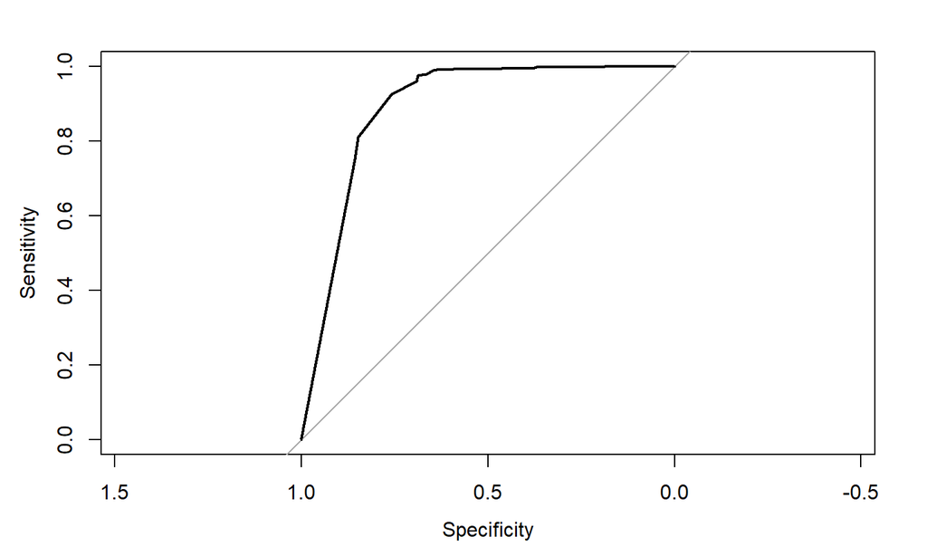

```r
roc_curve <- roc(churnTest$churn, dt_pred_prob$yes)
plot(roc_curve)
```

```r
auc(roc_curve)
```

```
## Area under the curve: 0.8914
```

## Hold Out Method (1)

```r
train_index <- sample(1:nrow(churnTrain), replace = F, size = nrow(churnTrain) * 0.8)
churnTrain2 <- churnTrain[train_index, ]
prop.table(table(churnTrain2$churn))
```

```
##
##       yes        no
## 0.1526632 0.8473368
```

```r
prop.table(table(churnTrain$churn))
```

```
##
##       yes        no
## 0.1449145 0.8550855
```